# 7: Generalized linear regressions

## So far

- Linear regressions
  - Linear relationship between outcome ~ predictor
  - Residuals normally distributed
- But not just a list of assumptions!
  - How are the data generated?
  - What shape do the data have? (boundaries, skew, …)
- If these mean that you’re not looking at a linear releationship, try a generalized linear model

## Learning outcomes

- Understand what is being generalized in a glm
- Understand family and link parameters
- Learn when to use 2 basic cases: Poisson and binomial
- Be able to extract useful information from the model

## Examples

- Normal(-ish) data generation
  - Height
  - Big-5 Personality traits
  - There are boundaries, but we’re seldom near them
- Non-normal data generation
  - Number of phonecalls to a call center evey 15 mins - Scores on a general knowledge test
  - Boundaries are meaningful
  - Shapes (can be) *very* non-normal

## Ok, so what does this data look like?

What features of this are quite different

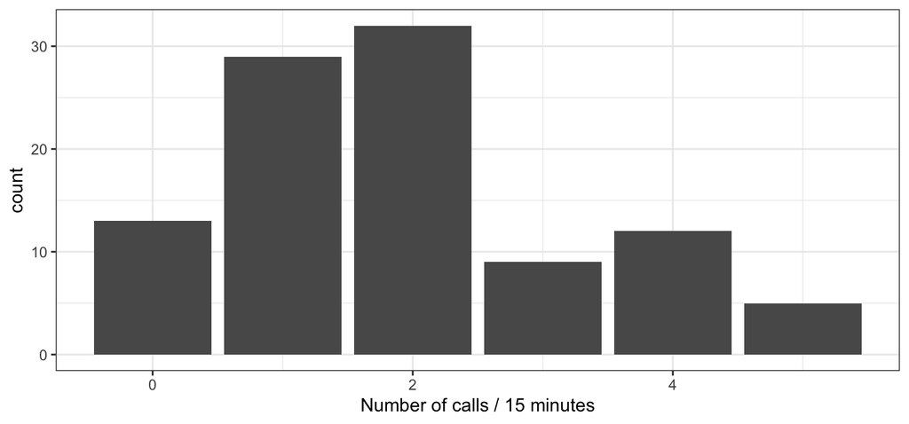

## Ok, so what does this data look like?

What features of this are quite different

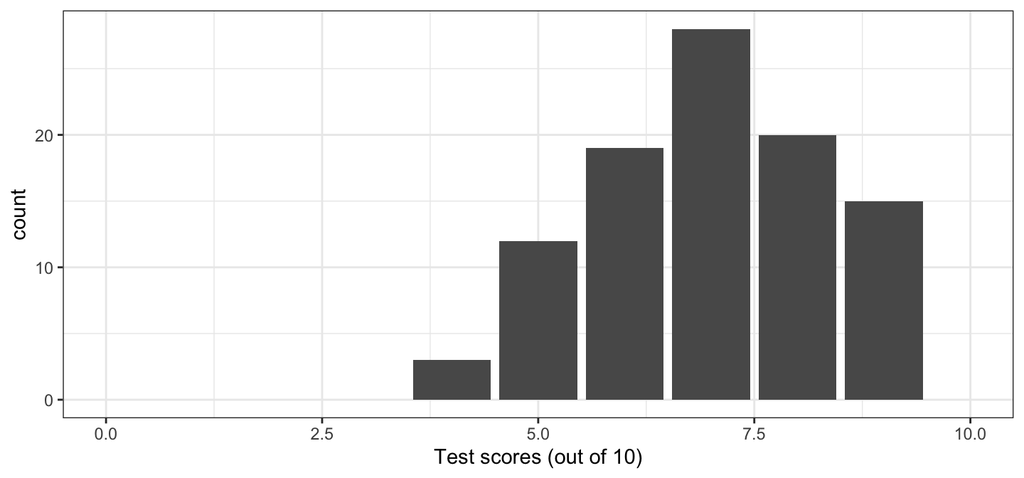

## Generalized linear regression can solve this!

Previously:

- \(y = b_0 + b_1x_1 ... + \epsilon\)
- \(Expected(y) = b_0 + b_1x_1 + ...\)

But why can’t \(Expected(y)\) have a more complex relationship with \(x\)?

usually, f(E(y)) = identity (like above)

But how about f(E(y)) = log, inverse, etc.?

## Generalized linear regression can solve this!

\(f(E(y)) = b_0 + b_1x_1 + ...\)

e.g.: \(log(E(y)) = b_0 + b_1x_1 + ...\)

vs. log transform: \(E(log(y)) = b_0 + b_1x_1 + ...\)

log-transformation transforms the data

glm transforms the expected value (and thus, something in the model)

## What’s so wrong with a linear regression?

- Linear regression thinks there aren’t any boundaries
- It can cope with non-normal data if you’re wanting to see if there’s a positive/negative relationship
- But the fit can seriously bias interpretation

## What’s so wrong with linear regression?

Fake data:

outcome: final exam pass = 1 vs. fail = 0; predictor: hours/week studying

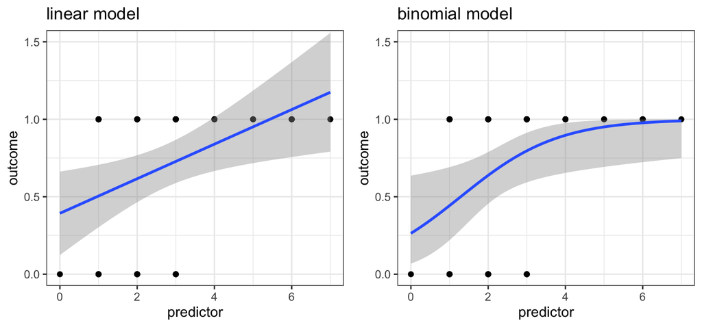

## What’s so wrong with linear regression?

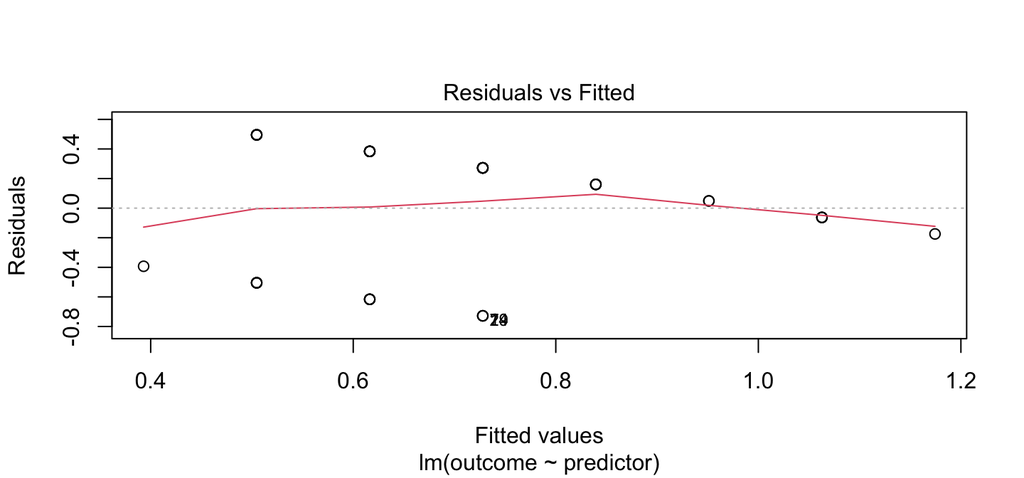

## What’s so wrong with linear regression?

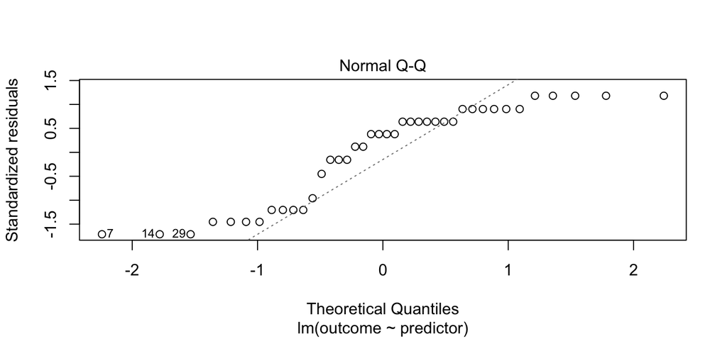

## Is it just about assumptions?

I think focusing on assumptions is *partly* missing the point: these are the symptoms of a problem, not the problem itself

One general theme in this workshop has been to explore the data, see how well we can explain an outcome based on some predictors

Sometimes a linear model is wrong just because it mis-characterizes your data

## Elements of a generalized linear model

A glm adds two things to an lm:

- you specify what distribution family your outcome variable belongs to
  - This is just the kind of thing we were talking about with callcenter calls/test scores: what kind of data do you have
  - see `?family` in RStudio
  - normal (gaussian), binomial, poisson, Gamma, inverse.gaussian, quasibinomial, quasipoisson,
- you optionally specify how the predictor and (expected) outcome are related
  - links: “identity”, “log”, “logit”, “inverse”, …

## Elements of a generalized linear model

Linear regression:

- `lm(y ~ x,data)`

Same as above:

- `glm(y ~ x,data, family=gaussian(link = "identity"))`

Change family and link

- `glm(y ~ x ,data,family=poisson(link = "log"))`

Or (since log is the “canonical” link for a Poisson regression)

- `glm(y ~ x,data,family=poisson)`

Basically, all you’re really doing is thinking “Hmm, my data isn’t normal, it looks Poisson, so tell the model that the family is Poisson”

## Elements of a generalized linear model

- So the `glm` allows you to control how your model fits the data in two ways: by specifying a *family* AND by specifying a *link* function
- a transformation (e.g. log(y)) is really just an attempt to handle these in one go:
  - link=“log” and *hopefully* the transformed data is normal-ish
  - Often doesn’t manage to do **both** jobs well
  - Some distributions can’t be transformed to normal

## Families

Setting a distribution family involves explicitly modeling:

- The **shape** of the data
  - e.g. skewed RT data
- The **range** of the data
  - e.g. positive (for RT data or count data)
  - between 0 and 1 (for a ratio)

## Families

Don’t start out by worrying what a Poisson/Gamma/negative binomial are

Start by thinking about your data and the processes that gave rise to it

See:

- https://www.essycode.com/distribution-viewer/

## Families

Eventually you can build up a sense of what to try

- google + crossvalidated + wikipedia
- literature, e.g.
  - Lo & Andrews, 2015, To transform or not to transform, Frontiers in Psych.
  - Coxe, West & Aiken, 2009, The analysis of count data, J. Pers. Assess.
- https://www.johndcook.com/blog/distribution_chart
- http://www.math.wm.edu/~leemis/chart/UDR/UDR.html

## Families

- Some rules of thumb
  - these are just starting points!
  - (… glossing over more complex relatives: e.g. poisson -> negative binomial)
  - (… glossing over things to watch out for: e.g. zero-inflation, overdispersion)
- count data: try Poisson
- success/failures: try binomial
- reaction time: try Gamma

## Summary

For lm, we were (tacitly) just specifying family=normal

But we can open this up to other families with a glm

Specifying `family` (and, optionally, `link`) is a more general, robust alternative to transformation in cases when a vanilla lm is problematic

It involves trying to model the data as it is, rather than trying to shoehorn the data into normality

## Expercise 1:

Data from https://stats.idre.ucla.edu/r/dae/logit-regression/

## Look at the data

```
## # A tibble: 6 x 4
##   admit   gre   gpa rank
##   <dbl> <dbl> <dbl> <fct>
## 1     0   380  3.61 3
## 2     1   660  3.67 3
## 3     1   800  4    1
## 4     1   640  3.19 4
## 5     0   520  2.93 4
## 6     1   760  3    2
```

## Look at the data

```
##      admit             gre             gpa        rank
##  Min.   :0.0000   Min.   :220.0   Min.   :2.260   1: 61
##  1st Qu.:0.0000   1st Qu.:520.0   1st Qu.:3.130   2:151
##  Median :0.0000   Median :580.0   Median :3.395   3:121
##  Mean   :0.3175   Mean   :587.7   Mean   :3.390   4: 67
##  3rd Qu.:1.0000   3rd Qu.:660.0   3rd Qu.:3.670
##  Max.   :1.0000   Max.   :800.0   Max.   :4.000
```

## Think about the outcome

Outcome `admit` has value 0 if an applicant wasn’t admitted to grad school, and 1 if they were

What kind of model are we likely to need?

## Run a regression

```r
mod_gradschool <- glm(...)

summary(mod_gradschool)
```

## Ok, so what does this all mean?

Linear regression, effects are additive:

- \(b_0 + b_1x_1 ...\)

Binomial regression, effects are a whole bunch of things:

- multiplicative
- log odds
- for now: negative = lowers chance of success; positive = raises chance of success
- https://stats.idre.ucla.edu/other/mult-pkg/faq/general/faq-how-do-i-interpret-odds-ratios-in-logistic-regression/

## Finding a way around the issue for now

`predict()` function

Give it some new data, use that to interpret the effects

Keep 2 columns constant, vary the 3rd to see what it does

```r
new_data <- data.frame(
  gre = mean(grad_school$gre),
  gpa = mean(grad_school$gpa),
  rank = factor(1:4))
```

## Finding a way around the issue for now

```r
new_data$expected_p <- predict(mod_gradschool, new_data, type="response")
new_data
```

```
##     gre    gpa rank expected_p
## 1 587.7 3.3899    1  0.5166016
## 2 587.7 3.3899    2  0.3522846
## 3 587.7 3.3899    3  0.2186120
## 4 587.7 3.3899    4  0.1846684
```

## Finding a way around the issue for now

- Try this again, but use other constants for `gre`, `gpa`
- Given that there’s no interaction here, do you expect it to make any difference?

## Finding a way around the issue for now

Vary 2 columns: gre and rank

Use newdata2 to predict the response values, and plot them with `aes(x=gre, color=rank)`

## Final warnings (if you’re actually going to use these)

For count data:

- Poisson is a quite basic option, but you may need a negative binomial instead (google: overdispersion)
- Check for zero-inflation
- See https://stats.idre.ucla.edu/other/dae/